# Reproducible Research: Peer Assessment 1

Yuan Wei

August 19, 2016

## Introduction

This is a submission for Coursera Data Science Specilization, Reproducible Research - Peer Graded Assignment: Course Project 1. The Github repository for this project can be found [here](https://github.com/rdpeng/RepData_PeerAssessment1).

Dplyr and ggplot2 pakages are required for this analysis.

```r
require(ggplot2)
require(dplyr)
```

## Loading & Processing Data

Read data from raw data in working directory:

```r
file <- read.csv(file = "activity.csv", header = TRUE, col.names = c("Steps", "Date", "Interval"))
clean.file <- file[complete.cases(file),]
```

Calculate the total number of steps taken per day and plot a histogram

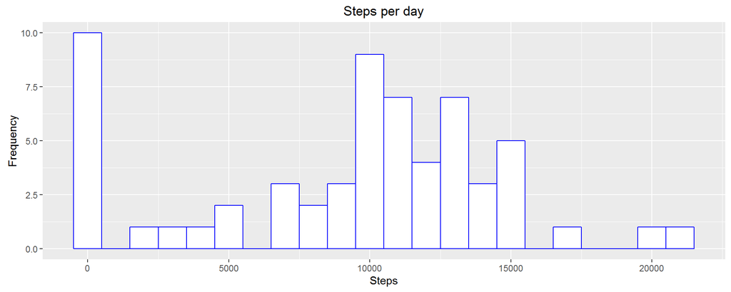

```r
steps.per.day.array <- tapply(file$Steps, file$Date, sum, na.rm=TRUE)
steps.per.day <- data.frame(names(steps.per.day.array), steps.per.day.array, row.names = NULL)
names(steps.per.day) <- c("Date", "Steps")

g <- ggplot(steps.per.day, aes(Steps))
g + geom_histogram(color = "blue", fill = "white", binwidth = 1000) +
  ggtitle("Steps per day") +
  xlab("Steps") +
  ylab("Frequency")
```

## What is mean total number of steps taken per day?

```r
summary(steps.per.day$Steps)
```

```
##    Min. 1st Qu.  Median    Mean 3rd Qu.    Max.
##       0    6778   10400    9354   12810   21190
```

## What is the average daily activity pattern?

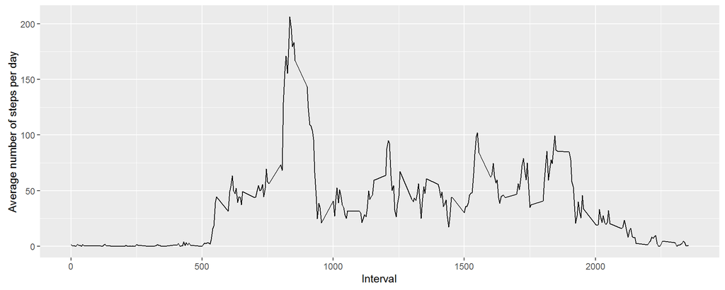

```r
ave.steps <- clean.file %>%
              group_by(Interval) %>%
              summarise(avg = mean(Steps))

g2 <- ggplot(ave.steps, aes(Interval, avg))
g2 +
  geom_line() +
  xlab("Interval") +
  ylab("Average number of steps per day")
```

Maximum number of steps

```r
max.step <- filter(ave.steps, avg==max(ave.steps$avg))
max.step
```

```
## Source: local data frame [1 x 2]
##
##   Interval      avg
##      (int)    (dbl)
## 1      835 206.1698
```

## Inputing missing values

Calculate and report the total number of missing values in the dataset (i.e. the total number of rows with NAs)

```r
no.na <- nrow(file[!complete.cases(file),])
no.na
```

```
## [1] 2304
```

Filling in all of the missing values in the dataset using means of day.

```r
ave.steps.per.day <- clean.file %>%
                      group_by(Date) %>%
                      summarise(avg = mean(Steps))
ave.steps.per.day <- rbind(ave.steps.per.day, c("2012-10-01", 0))

findvalue <- function(row) {
  test <- length(ave.steps.per.day$avg[grep(as.character(fill.file$Date[row]), ave.steps.per.day$Date)])
  if (test == 0) {
    return(0)
  } else {
    return(ave.steps.per.day$avg[grep(as.character(fill.file$Date[row]), ave.steps.per.day$Date)])
  }
}

fill.file <- file
for (row in 1:nrow(fill.file)) {
  if (is.na(fill.file$Steps[row])) {
    fill.file$Steps[row] <- as.numeric(findvalue(row))
  }
}
```

Check if new dataset that is equal to the original dataset but with the missing data filled in.

Initial data set with NAs :

```r
summary(steps.per.day$Steps)
```

```
##    Min. 1st Qu.  Median    Mean 3rd Qu.    Max.
##       0    6778   10400    9354   12810   21190
```

New data set will filled value :

```r
new.steps.per.day.array <- tapply(fill.file$Steps, fill.file$Date, sum, na.rm=TRUE)
new.steps.per.day <- data.frame(names(new.steps.per.day.array), new.steps.per.day.array, row.names = NULL)
names(new.steps.per.day) <- c("Date", "Steps")
summary(new.steps.per.day$Steps)
```

```
##    Min. 1st Qu.  Median    Mean 3rd Qu.    Max.
##       0    6778   10400    9354   12810   21190
```

Histogram of the total number of steps taken each day using new data set with replaced NAs

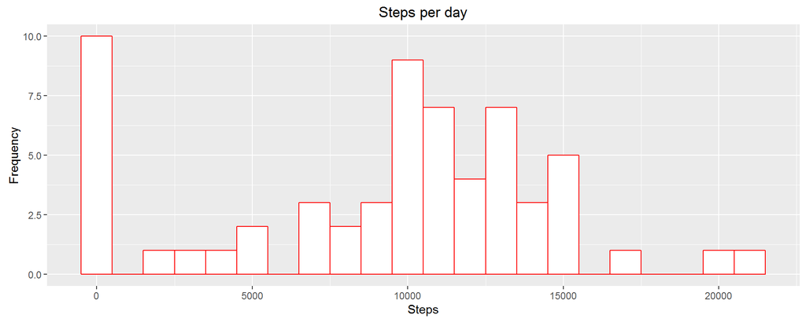

```r
fill.steps.per.day.array <- tapply(fill.file$Steps, fill.file$Date, sum, na.rm=TRUE)
fill.steps.per.day <- data.frame(names(fill.steps.per.day.array), fill.steps.per.day.array, row.names = NULL)
names(fill.steps.per.day) <- c("Date", "Steps")

g3 <- ggplot(fill.steps.per.day, aes(Steps))
g3 + geom_histogram(color = "red", fill = "white", binwidth = 1000) +
    ggtitle("Steps per day") +
    xlab("Steps") +
    ylab("Frequency")
```

Based on the calculations and figure above, we can see that new data set with replaced NAs values has no impact on its mean, median and distribution.

## Are there differences in activity patterns between weekdays and weekends?

Plot containing a time series plot of the 5-minute interval (x-axis) and the average number of steps taken, averaged across all weekday days or weekend days (y-axis):

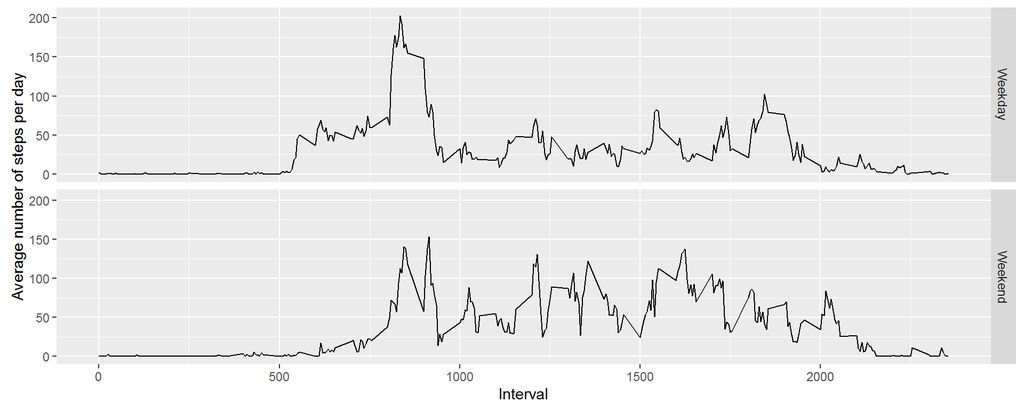

```r
fill.file$Date <- as.Date(fill.file$Date)
fill.file$Day <- weekdays(fill.file$Date)

weekday <- filter(fill.file, Day == "Monday" | Day == "Tuesday" | Day == "Wednesday" | Day == "Thursday" | Day == "Friday")

weekend <- filter(fill.file, Day == "Saturday" | Day == "Sunday")

weekday.ave.steps <- weekday %>%
              group_by(Interval) %>%
              summarise(avg = mean(Steps)) %>%
              cbind("Weekday")
names(weekday.ave.steps) <- c("Interval", "avg", "daysofweek")

weekend.ave.steps <- weekend %>%
              group_by(Interval) %>%
              summarise(avg = mean(Steps)) %>%
              cbind("Weekend")
names(weekend.ave.steps) <- c("Interval", "avg", "daysofweek")

week.ave.steps <- rbind(weekday.ave.steps, weekend.ave.steps)

g4 <- ggplot(week.ave.steps, aes(Interval, avg)) +
        geom_line() +
        xlab("Interval") +
        ylab("Average number of steps per day")

g4 + facet_grid(daysofweek ~ .)
```